# California Housing Price Prediction: Moving Beyond Linearity

Nonparametric Regression Project

Alpha Numeric Group 1

2026-05-17

# 1 Introduction & Objectives

This project applies the nonparametric and semi-parametric regression techniques to the California Housing dataset. The central thesis is that the relationship between housing price and its predictors is **inherently nonlinear and spatially interactive**, a claim we test rigorously by comparing a full ladder of model families.

**Research Questions**

1. Can ensemble nonlinear models (Random Forest, XGBoost, Neural Network) predict house prices more accurately than classical approaches? What are the most important nonlinear interactions between location and income?
2. Which model family — **GNPR** (GAM, Kernel/Local Regression, Splines, Step Functions, Polynomial) vs. **Parametric** (Linear, Ridge) vs. **Machine Learning** (RF, XGBoost, NN) — provides the best predictive accuracy?

**Model Ladder**

| # | Model | Family |
| --- | --- | --- |
| 1 | Multiple Linear Regression | Parametric (baseline) |
| 2 | Polynomial Regression (degree 3) | GNPR |
| 3 | Step Function Regression | GNPR |
| 4 | Regression Splines (B-splines, Natural Splines) | GNPR |
| 5 | Smoothing Spline (via GAM `s()`) | GNPR |
| 6 | Local Regression (LOESS) | GNPR |
| 7 | Generalized Additive Model (GAM + tensor interactions) | GNPR |
| 8 | Random Forest | ML Ensemble |
| 9 | XGBoost | ML Ensemble |
| 10 | Neural Network (MLP) | ML / Deep Learning |

# 2 Package Installation & Loading

```r
# Install any missing packages
required_pkgs <- c(
  "tidyverse", "caret", "randomForest", "xgboost",
  "mgcv", "splines", "np", "corrplot", "gridExtra",
  "Metrics", "neuralnet", "ggplot2", "viridis", "scales",
  "pdp", "vip", "spdep", "sf", "kableExtra", "GGally",
  "patchwork", "ggrepel"
)

new_pkgs <- required_pkgs[!required_pkgs %in% rownames(installed.packages())]
if (length(new_pkgs) > 0) {
  install.packages(new_pkgs, dependencies = TRUE, repos = "https://cloud.r-project.org")
}

# Load libraries
suppressPackageStartupMessages({
  library(tidyverse)
  library(caret)
  library(randomForest)
  library(xgboost)
  library(mgcv)          # GAM, smoothing splines
  library(splines)       # bs(), ns()
  library(np)            # Kernel / local regression
  library(corrplot)
  library(gridExtra)
  library(Metrics)       # rmse(), mae()
  library(neuralnet)
  library(ggplot2)
  library(viridis)
  library(scales)
  library(pdp)           # Partial Dependence Plots
  library(vip)           # Variable Importance Plots
  library(spdep)         # Moran's I
  library(sf)
  library(kableExtra)
  library(GGally)
  library(patchwork)
  library(ggrepel)
})

# Global ggplot theme
theme_set(theme_minimal(base_size = 12) +
            theme(plot.title = element_text(face = "bold", size = 13),
                  plot.subtitle = element_text(color = "grey40")))
```

# 3 Data Loading & Initial Inspection

```r
# Load dataset (no header row)
data <- read.csv("C:/Users/HP/OneDrive - Strathmore University/STRATH UNI/FIRST YEAR/SEMESTER III/UNITS/LINEAR MODELS/LINEAR-MODELS/Data/cal_housing.data", header = FALSE)


colnames(data) <- c("longitude", "latitude", "housing_median_age",
  "total_rooms", "total_bedrooms", "population",
  "households", "median_income", "median_house_value"
)


cat("Dimensions       :", dim(data), "\n")
```

```
#> Dimensions       : 20640 9
```

```r
cat("Missing values   :", sum(is.na(data)), "\n")
```

```
#> Missing values   : 0
```

```r
head(data, 6)
```

|  | longitude | latitude | housing_median_age | total_rooms | total_bedrooms | population | households | median_income | median_house_value |
| --- | --- | --- | --- | --- | --- | --- | --- | --- | --- |
| 1 | -122.23 | 37.88 | 41 | 880 | 129 | 322 | 126 | 8.3252 | 452600 |
| 2 | -122.22 | 37.86 | 21 | 7099 | 1106 | 2401 | 1138 | 8.3014 | 358500 |
| 3 | -122.24 | 37.85 | 52 | 1467 | 190 | 496 | 177 | 7.2574 | 352100 |
| 4 | -122.25 | 37.85 | 52 | 1274 | 235 | 558 | 219 | 5.6431 | 341300 |
| 5 | -122.25 | 37.85 | 52 | 1627 | 280 | 565 | 259 | 3.8462 | 342200 |
| 6 | -122.25 | 37.85 | 52 | 919 | 213 | 413 | 193 | 4.0368 | 269700 |

```r
summary(data)
```

```
#>    longitude         latitude     housing_median_age  total_rooms
#>  Min.   :-124.3   Min.   :32.54   Min.   : 1.00      Min.   :    2
#>  1st Qu.:-121.8   1st Qu.:33.93   1st Qu.:18.00      1st Qu.: 1448
#>  Median :-118.5   Median :34.26   Median :29.00      Median : 2127
#>  Mean   :-119.6   Mean   :35.63   Mean   :28.64      Mean   : 2636
#>  3rd Qu.:-118.0   3rd Qu.:37.71   3rd Qu.:37.00      3rd Qu.: 3148
#>  Max.   :-114.3   Max.   :41.95   Max.   :52.00      Max.   :39320
#>  total_bedrooms     population      households     median_income
#>  Min.   :   1.0   Min.   :    3   Min.   :   1.0   Min.   : 0.4999
#>  1st Qu.: 295.0   1st Qu.:  787   1st Qu.: 280.0   1st Qu.: 2.5634
#>  Median : 435.0   Median : 1166   Median : 409.0   Median : 3.5348
#>  Mean   : 537.9   Mean   : 1425   Mean   : 499.5   Mean   : 3.8707
#>  3rd Qu.: 647.0   3rd Qu.: 1725   3rd Qu.: 605.0   3rd Qu.: 4.7432
#>  Max.   :6445.0   Max.   :35682   Max.   :6082.0   Max.   :15.0001
#>  median_house_value
#>  Min.   : 14999
#>  1st Qu.:119600
#>  Median :179700
#>  Mean   :206856
#>  3rd Qu.:264725
#>  Max.   :500001
```

```r
cat(strrep("*", 100)) # To divide the output
# checking unique values
sapply(data, function(x) length(unique(x)))
```

```
#>          longitude           latitude housing_median_age        total_rooms
#>                844                862                 52               5926
#>     total_bedrooms         population         households      median_income
#>               1928               3888               1815              12928
#> median_house_value
#>               3842
```

# 4 Exploratory Data Analysis

## 4.1 Distributions of All Variables

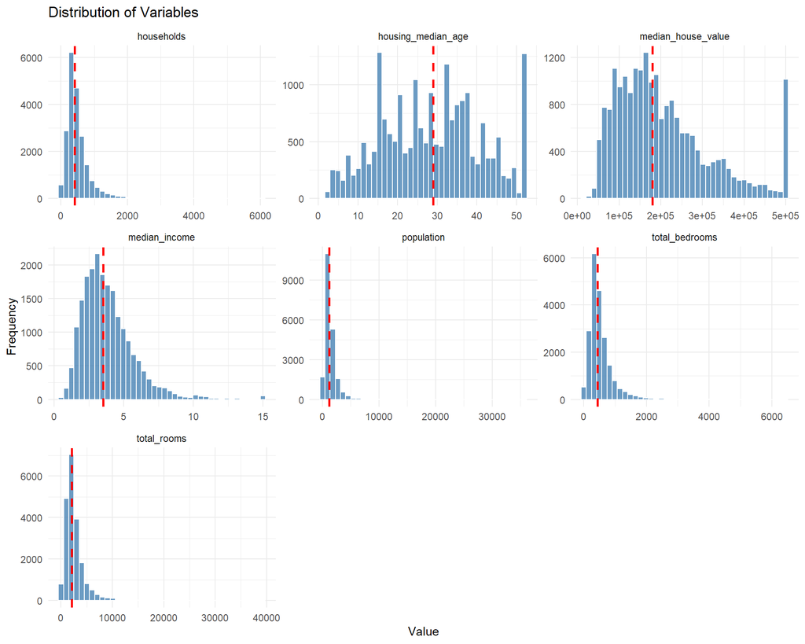

```r
# 1. Calculating the medians for each variable first
medians_data <- data %>%
  select(-c(longitude, latitude)) %>%
  pivot_longer(everything(), names_to = "variable", values_to = "value") %>%
  group_by(variable) %>%
  summarize(median_val = median(value, na.rm = TRUE))

# 2. Pivoting the main data
data_long <- data %>%
  select(-c(longitude, latitude)) %>%
  pivot_longer(everything(), names_to = "variable", values_to = "value")

# 3. Plotting then adding the medians_data to the geom_vline
ggplot(data_long, aes(x = value)) +
  geom_histogram(bins = 40, fill = "steelblue", color = "white", alpha = 0.8) +
  geom_vline(data = medians_data, aes(xintercept = median_val), color = "red", linetype = "dashed", size = 1) +
  facet_wrap(~variable, scales = "free") +
  theme_minimal() +
  labs(title = "Distribution of Variables", x = "Value", y = "Frequency")
```

```r
cat("The highest value for housing median age is:", max(data$housing_median_age), "\n")
```

```
#> The highest value for housing median age is: 52
```

```r
cat("The highest median house value is:", max(data$median_house_value), "\n")
```

```
#> The highest median house value is: 500001
```

```r
cat("The highest median income is:", max(data$median_income), "\n")
```

```
#> The highest median income is: 15.0001
```

With that, we proceeded to filter the dataset.

```r
# Creating a clean, uncapped dataset
clean_data <- data %>%
  filter(median_house_value < 500000) %>%
  filter(housing_median_age < 52) %>%
  filter(median_income < 15)

# Checking # of lost rows
print(paste("Original rows:", nrow(data)))
```

```
#> [1] "Original rows: 20640"
```

```r
print(paste("Cleaned rows:", nrow(clean_data)))
```

```
#> [1] "Cleaned rows: 18553"
```

From the filtering, we lost 2087 rows of data, a sacrifice for statistical accuracy.

## 4.2 Correlation Structure

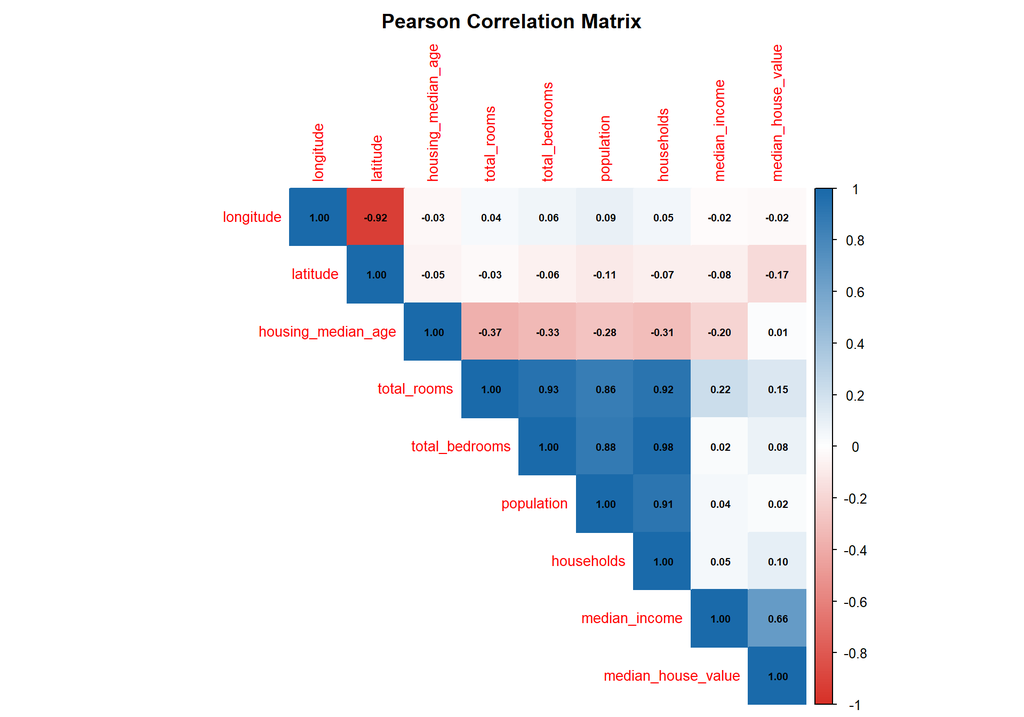

```r
cor_matrix <- cor(clean_data, use = "complete.obs")
corrplot(
  cor_matrix,
  method      = "color",
  type        = "upper",
  tl.cex      = 0.85,
  addCoef.col = "black",
  number.cex  = 0.60,
  col         = colorRampPalette(c("#d73027","white","#1a6aaa"))(200),
  title       = "Pearson Correlation Matrix",
  mar         = c(0, 0, 2, 0)
)
```

There were highly strong correlations amongst certain variables such as total_rooms, total_bedrooms, population and households.  
We also saw a relatively strong correlation between median_income and median_house_value.

We then generated the final fit summary table which informed us of the important variables influencing the median house prices.

```r
# Loading required formatting packages
library(finalfit)
library(kableExtra)
library(dplyr)

# 1. Creating categorical dependent variable using existing 'clean_data'
summary_data <- clean_data %>%
  mutate(
    house_value_group = ntile(median_house_value, 4) %>%
      factor(labels = c("Low", "Medium", "High", "Very High"))
  )

# 2. Defining dependent and explanatory variables
dependent <- "house_value_group"

# Selecting all columns except targets and geographical coordinates
explanatory <- summary_data %>%
  select(-median_house_value, -house_value_group, -longitude, -latitude) %>%
  names()

# 3. Creating the summary factorlist
table1 <- summary_data %>%
  summary_factorlist(
    dependent = dependent,
    explanatory = explanatory,
    p = TRUE,              # Includes p-values for statistical differences
    cont = "median",       # Used median for continuous variables (handles skewness well)
    column = TRUE,
    total_col = TRUE,
    na_include = TRUE
  )

# 4. Rendering as a formatted HTML table
table1 %>%
  kbl(
    caption = "Table 1: Summary Statistics by House Value Quartile",
    align = "lcccccc",
    booktabs = FALSE
  ) %>%
  kable_styling(
    bootstrap_options = c("striped", "bordered", "hover"),
    full_width = FALSE
  ) %>%
  row_spec(0, bold = TRUE)
```

Table 1: Summary Statistics by House Value Quartile

| label | levels | Low | Medium | High | Very High | Total | p |
| --- | --- | --- | --- | --- | --- | --- | --- |
| housing_median_age | Median (IQR) | 28.0 (18.0 to 36.0) | 26.0 (16.0 to 36.0) | 28.0 (18.0 to 35.0) | 27.0 (18.0 to 36.0) | 27.0 (17.0 to 36.0) | <0.001 |
| total_rooms | Median (IQR) | 1802.0 (1228.0 to 2612.0) | 2037.0 (1400.2 to 3079.5) | 2221.5 (1529.2 to 3241.8) | 2550.5 (1755.0 to 3770.8) | 2142.0 (1455.0 to 3184.0) | <0.001 |
| total_bedrooms | Median (IQR) | 395.0 (271.0 to 573.0) | 448.0 (303.0 to 666.0) | 461.0 (311.2 to 696.0) | 469.0 (319.0 to 715.8) | 442.0 (300.0 to 659.0) | <0.001 |
| population | Median (IQR) | 1100.0 (733.5 to 1579.0) | 1302.5 (863.0 to 1932.0) | 1265.0 (855.0 to 1872.8) | 1179.0 (808.0 to 1750.5) | 1204.0 (811.0 to 1781.0) | <0.001 |
| households | Median (IQR) | 361.0 (248.5 to 521.0) | 419.0 (287.0 to 616.8) | 434.5 (297.0 to 652.0) | 448.0 (309.0 to 665.8) | 416.0 (284.0 to 614.0) | <0.001 |
| median_income | Median (IQR) | 2.3 (1.8 to 3.0) | 3.2 (2.5 to 4.0) | 3.9 (3.1 to 4.7) | 5.1 (3.9 to 6.2) | 3.5 (2.5 to 4.6) | <0.001 |

The above variables had p-values less than 0.05 thus proving to be significant.

## 4.3 Geographic Distribution

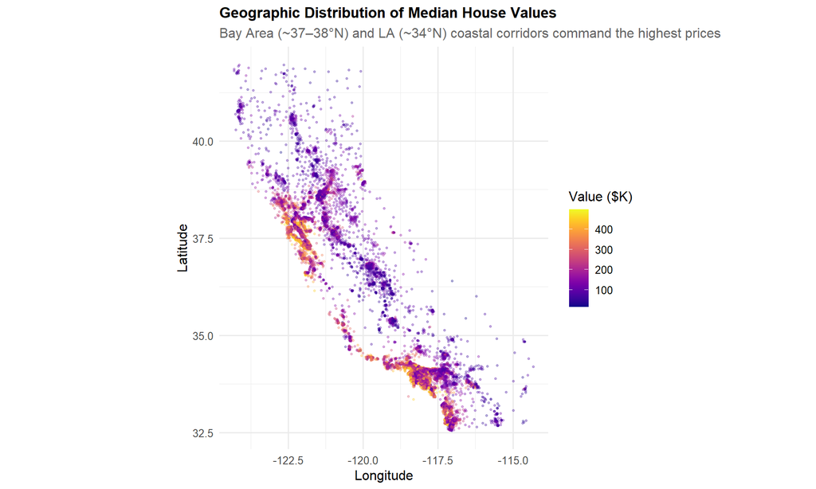

```r
ggplot(clean_data, aes(x = longitude, y = latitude, color = median_house_value / 1e3)) +
  geom_point(alpha = 0.25, size = 0.7) +
  scale_color_viridis(name = "Value ($K)", option = "C", labels = comma) +
  coord_fixed(ratio = 1.3) +
  labs(
    title    = "Geographic Distribution of Median House Values",
    subtitle = "Bay Area (~37–38°N) and LA (~34°N) coastal corridors command the highest prices",
    x = "Longitude", y = "Latitude"
  )
```

-Expensive neighborhoods tend to be geographically grouped together. This will also be evidenced by the subsequent Moran Scatter Plots. Additionally, expensive neighborhoods are on the western part of California near the ocean while cheaper houses are located towards the inland side.

## 4.4 Spatial Autocorrelation — Moran’s I Test

This is used to explore how a variable at a specific location relates to its neighbouring location (how similar an observed value is to its neighboring observations).

```r
# Build spatial object and k-NN weights (k = 5)
spatial_obj <- st_as_sf(clean_data, coords = c("longitude", "latitude"), crs = 4326)
coords      <- st_coordinates(spatial_obj)
knn5        <- knn2nb(knearneigh(coords, k = 5))
lw          <- nb2listw(knn5, style = "W")

# Moran's I — median income
moran_income <- moran.test(clean_data$median_income, lw)
cat("Moran's I (median_income)      :", round(moran_income$estimate["Moran I statistic"], 4), "\n")
```

```
#> Moran's I (median_income)      : 0.5894
```

```r
cat("p-value                        :", format(moran_income$p.value, scientific = TRUE), "\n")
```

```
#> p-value                        : 0e+00
```

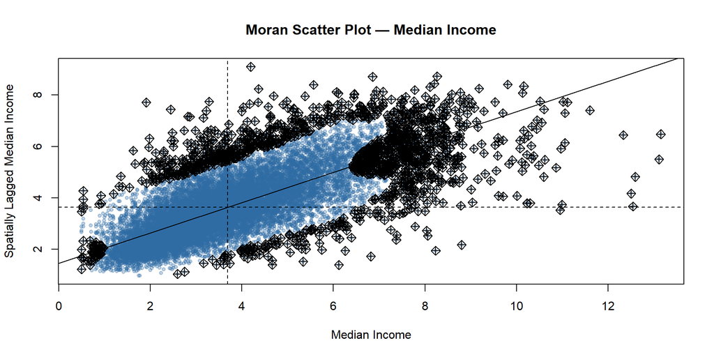

```r
moran.plot(
  clean_data$median_income, lw,
  labels = FALSE,
  main   = "Moran Scatter Plot — Median Income",
  xlab   = "Median Income", ylab = "Spatially Lagged Median Income",
  pch    = 20, col = rgb(0.18, 0.42, 0.64, 0.3)
)
```

#### 4.4.0.1 Observations/Discussions

*Density*: Most data points (the blue cloud) are concentrated in the Low-Low and High-High quadrants, confirming that clustering is the dominant spatial pattern.

The positive slope of the regression line indicates positive spatial autocorrelation. This means that high-income areas tend to be near other high-income areas and low-income areas cluster together. The slope of this line is the Global Moran’s I value.

The Moran I statistic was 0.5894. This indicated a strong positive spatial autocorrelation, showing that median income levels are significantly clustered across the region. It confirmed that income is highly dependent on neighboring areas as seen that wealthy neighborhoods tend to cluster together, so do lower-income ones. The p-value was essentially zero, meaning the probability of this spatial pattern occurring by pure chance was non-existent, proving that geography played a fundamental role in income distribution.

```r
# Moran's I — house value
moran_value <- moran.test(clean_data$median_house_value, lw)
cat("Moran's I (median_house_value) :", round(moran_value$estimate["Moran I statistic"], 4), "\n")
```

```
#> Moran's I (median_house_value) : 0.7745
```

```r
cat("p-value                        :", format(moran_value$p.value, scientific = TRUE), "\n")
```

```
#> p-value                        : 0e+00
```

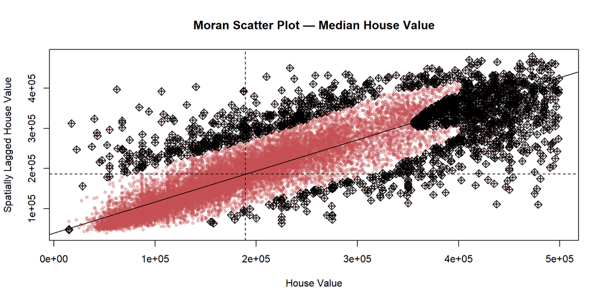

```r
moran.plot(
  clean_data$median_house_value, lw,
  labels = FALSE,
  main   = "Moran Scatter Plot — Median House Value",
  xlab   = "House Value", ylab = "Spatially Lagged House Value",
  pch    = 20, col = rgb(0.77, 0.31, 0.32, 0.3)
)
```

This second plot is also similar to the previous one as explained below.

#### 4.4.0.2 Observations and discussions

*Density*: Most data points (the red cloud) are concentrated in the Low-Low quadrants. It represents large areas of more affordable housing grouped together. The Top-Right shows the “luxury” clusters where houses are expensive.

The strong upward slope confirms positive spatial autocorrelation. Expensive houses are overwhelmingly located next to other expensive houses, and cheaper houses cluster with other cheaper houses.

The Moran I statistic was 0.7745. This indicated extremely strong positive spatial autocorrelation. It confirms that house values are not just slightly clustered, that they are very heavily dependent on their neighbours. The P-Value was was close to zero. This meant that the probability that this clustering happened by pure chance is non-existent thus proving that location is a massive factor in house values.

## 4.5 Nonlinearity: Income vs. House Value

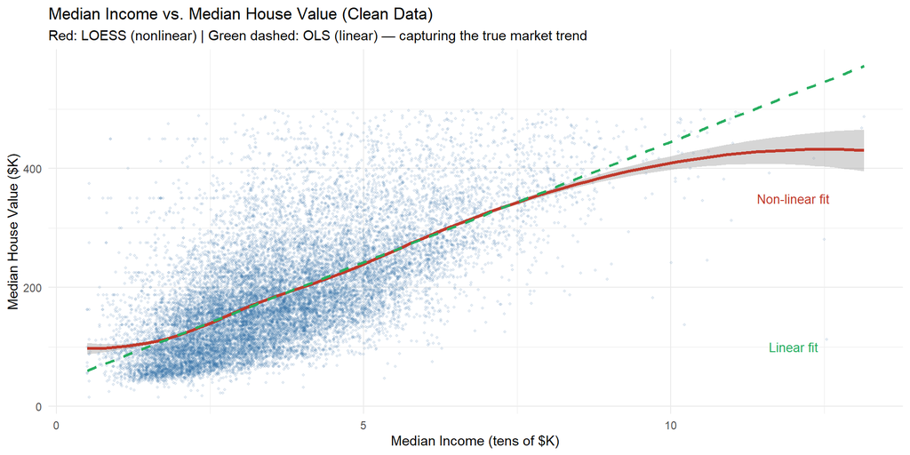

```r
ggplot(clean_data, aes(x = median_income, y = median_house_value / 1e3)) +
  geom_point(alpha = 0.12, color = "#2e6da4", size = 0.7) +
  geom_smooth(method = "loess", formula = y ~ x,
              color = "#c0392b", linewidth = 1.2, se = TRUE) +
  geom_smooth(method = "lm", color = "#27ae60", linewidth = 1, se = FALSE,
              linetype = "dashed") +
  labs(
    title    = "Median Income vs. Median House Value (Clean Data)",
    subtitle = "Red: LOESS (nonlinear) | Green dashed: OLS (linear) — capturing the true market trend",
    x = "Median Income (tens of $K)", y = "Median House Value ($K)"
  ) +
  annotate("text", x = 12, y = 100, label = "Linear fit", color = "#27ae60", size = 3.5) +
  annotate("text", x = 12, y = 350, label = "Non-linear fit", color = "#c0392b", size = 3.5) +
  theme_minimal()
```

### 4.5.1 Interpretation of Median Income vs. Median House Value

The scatter plot visualizes the relationship between Median Income ($X$, in tens of thousands of USD) and Median House Value ($Y$, in thousands of USD). This was to compare a simple linear regression fit (OLS) against a local regression fit (LOESS).

#### 4.5.1.1 1. Evidence of Non-Linearity and Local Fit

$$\beta = \frac{\partial Y}{\partial
X}$$

The red solid LOESS line gave a whole different story whereby it uncovered an **S-curve (sigmoidal) dynamic**. At lower income brackets, house values remained relatively flat. This followed by a steep, linear acceleration phase as income grows, before ultimately plateauing.

#### 4.5.1.2 2. Synthesis with Spatial Findings

This non-linear relationship complemented our spatial diagnostics. Given that Global Moran’s $I$ proved both variables are highly spatially dependent ($\text{I}_{\text{house}} = 0.7745$ and $\text{I}_{\text{income}} = 0.5894$), we inferred that:  
* Neighborhoods are clustered by income brackets due to economic segregation of some sorts.

**Conclusion:** Using a standard linear model for prediction here would introduce severe systemic bias. To properly model these data dynamics, we needed to implement non-linear specifications—such as polynomial terms, regression splines (B-Splines/Natural Splines) or generalized additive models (GAMs)—while simultaneously addressing spatial autocorrelation.

[output not shown]

# 5 Model 1 — Multiple Linear Regression (Baseline)

**Theoretical basis:** The standard parametric model assumes:

$$y_i = \beta_0 + \beta_1 x_{i1} + \cdots
+ \beta_p x_{ip} + \varepsilon_i$$

This imposes linearity and additivity, a restriction we will systematically relax in subsequent models.

```r
# Training the model
lm_formula <- as.formula(
  paste("median_house_value ~", paste(features_all, collapse = " + "))
)
lm_model <- lm(lm_formula, data = train_sc)

# Printing the training summary
summary(lm_model)
```

```
#>
#> Call:
#> lm(formula = lm_formula, data = train_sc)
#>
#> Residuals:
#>     Min      1Q  Median      3Q     Max
#> -441794  -39038  -10334   28511  371521
#>
#> Coefficients:
#>                          Estimate Std. Error t value Pr(>|t|)
#> (Intercept)              189267.2      498.8 379.447  < 2e-16 ***
#> longitude                -72442.7     1467.7 -49.356  < 2e-16 ***
#> latitude                 -75315.7     1512.8 -49.787  < 2e-16 ***
#> housing_median_age         7004.6      532.5  13.154  < 2e-16 ***
#> median_income             69151.6      726.3  95.205  < 2e-16 ***
#> rooms_per_household        5917.5      574.5  10.300  < 2e-16 ***
#> bedrooms_per_room         20806.0      700.9  29.686  < 2e-16 ***
#> population_per_household  -3750.4      499.8  -7.503 6.57e-14 ***
#> ---
#> Signif. codes:  0 '***' 0.001 '**' 0.01 '*' 0.05 '.' 0.1 ' ' 1
#>
#> Residual standard error: 60770 on 14837 degrees of freedom
#> Multiple R-squared:  0.5927, Adjusted R-squared:  0.5925
#> F-statistic:  3084 on 7 and 14837 DF,  p-value: < 2.2e-16
```

```r
# Predicting on the unseen Test Set
lm_preds <- predict(lm_model, newdata = test_sc)

# Calculating RMSE, MAE, R^2
lm_metrics <- calc_metrics(actual = y_test, predicted = lm_preds, model_name = "1. Multiple Linear Regression")

# Saving the results for later comparison
all_metrics[[1]] <- lm_metrics
all_preds[["MLR"]] <- lm_preds

# Printing the final grades for this model
print(lm_metrics)
```

```
#> # A tibble: 1 × 4
#>   Model                           RMSE    MAE    R2
#>   <chr>                          <dbl>  <dbl> <dbl>
#> 1 1. Multiple Linear Regression 59905. 44567. 0.611
```

**Interpretations and Discussions** The multiple regression model gave us an Adjusted R-squared of 0.5925 . This told us that the model explained about 59.25% of the data as 40.75% of the variations were to be accounted for by other factors not included in the model.

From our test data, we obtained RMSE of 59905. This explains that the model was off by $ 59905 in predicting house prices. As this was our base model, our goal was to improve by lowering the RMSE. The R2 on the test was 61.1% which was not afar off from the train data R2. It explained 61.1% of the variation.

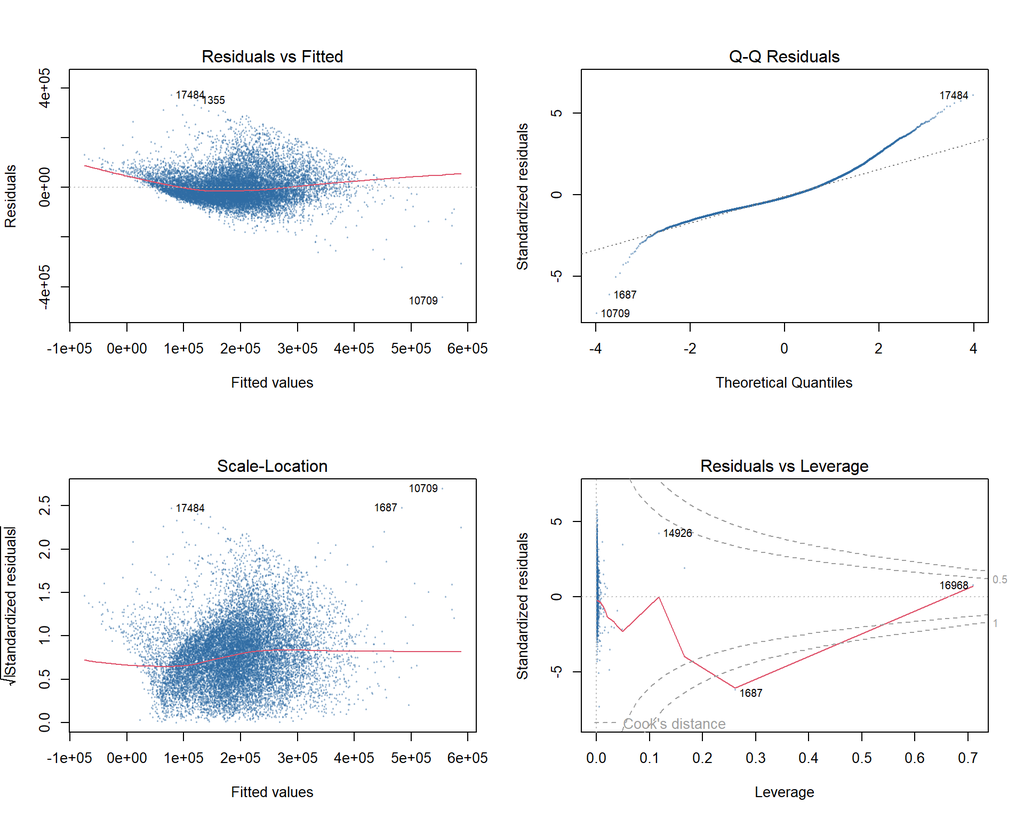

```r
par(mfrow = c(2, 2))
plot(lm_model, pch = 20, cex = 0.4, col = rgb(0.18, 0.42, 0.64, 0.3))
```

```r
par(mfrow = c(1, 1))
```